# 市场观察

2016/06/23

## 一、指数估值

### (一)指数动态市盈率

核心指数成分股的动态市盈率中位数走势如下图所示：

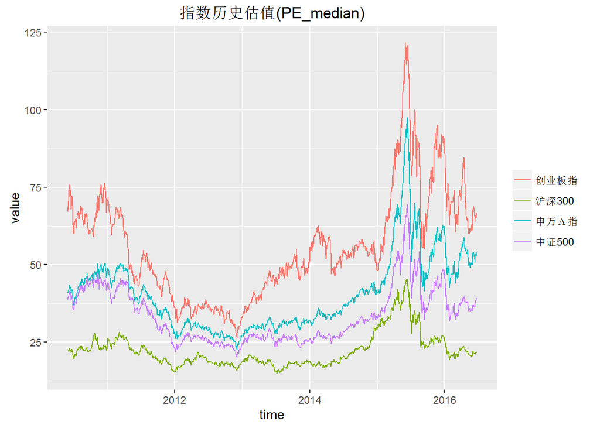

### (二)指数动态市盈率百分位

核心指数上述数据的百分位走势如下图所示：

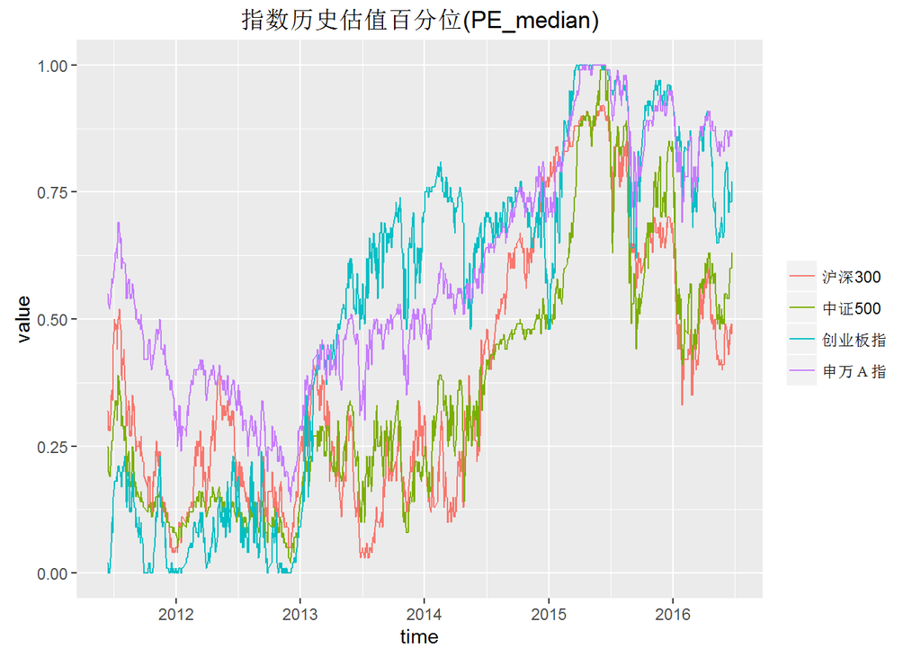

### (三)指数估值概览

纳入观察的18只指数最新的估值情况如下表：

| 日期 | 指数代码 | 指数简称 | 动态市盈率 | 上周动态市盈率 | 市盈率百分位 | 上周市盈率百分位 | 动态市净率 | 市净率百分位 |
| --- | --- | --- | --- | --- | --- | --- | --- | --- |
| 2016-06-22 | EI000979 | 大宗商品 | 44.48 | 44.21 | 0.92 | 0.92 | 2.53 | 0.47 |
| 2016-06-22 | EI000819 | 有色金属 | 57.36 | 57.64 | 0.87 | 0.87 | 4.23 | 0.88 |
| 2016-06-22 | EI801003 | 申万Ａ指 | 53.96 | 52.84 | 0.87 | 0.86 | 4.58 | 0.72 |
| 2016-06-22 | EI000805 | A股资源 | 43.94 | 43.42 | 0.82 | 0.82 | 2.41 | 0.51 |
| 2016-06-22 | EI399005 | 中小板指P | 45.08 | 44.38 | 0.81 | 0.79 | 5.24 | 0.61 |
| 2016-06-22 | EI399959 | 军工指数 | 91.63 | 88.80 | 0.80 | 0.77 | 5.85 | 0.75 |
| 2016-06-22 | EI399006 | 创业板指 | 66.69 | 65.98 | 0.77 | 0.75 | 7.51 | 0.78 |
| 2016-06-22 | EI000998 | 中证TMT | 57.60 | 56.96 | 0.76 | 0.74 | 5.82 | 0.74 |
| 2016-06-22 | EI801120 | 申万食品饮料 | 43.52 | 42.68 | 0.66 | 0.64 | 4.36 | 0.54 |
| 2016-06-22 | EI000905 | 中证500 | 39.23 | 37.59 | 0.63 | 0.57 | 3.44 | 0.53 |
| 2016-06-22 | EI000808 | 医药生物 | 39.42 | 39.07 | 0.52 | 0.47 | 5.05 | 0.45 |
| 2016-06-22 | EI000933 | 中证医药 | 36.84 | 36.83 | 0.52 | 0.52 | 4.37 | 0.25 |
| 2016-06-22 | EI399330 | 深证100 | 26.46 | 26.25 | 0.51 | 0.50 | 3.79 | 0.58 |
| 2016-06-22 | EI000300 | 沪深300 | 21.88 | 21.49 | 0.49 | 0.46 | 2.45 | 0.42 |
| 2016-06-22 | EI000932 | 中证消费 | 32.33 | 31.92 | 0.48 | 0.46 | 4.16 | 0.39 |
| 2016-06-22 | EI000827 | 中证环保 | 35.97 | 35.80 | 0.38 | 0.37 | 3.81 | 0.60 |
| 2016-06-22 | EI000934 | 中证金融 | 14.86 | 14.80 | 0.22 | 0.21 | 2.14 | 0.42 |
| 2016-06-22 | EI000016 | 上证50 | 11.73 | 11.70 | 0.07 | 0.06 | 1.43 | 0.02 |

## 二、基差

### (一)基差走势

三大股指期货隔季合约基差走势如下图：

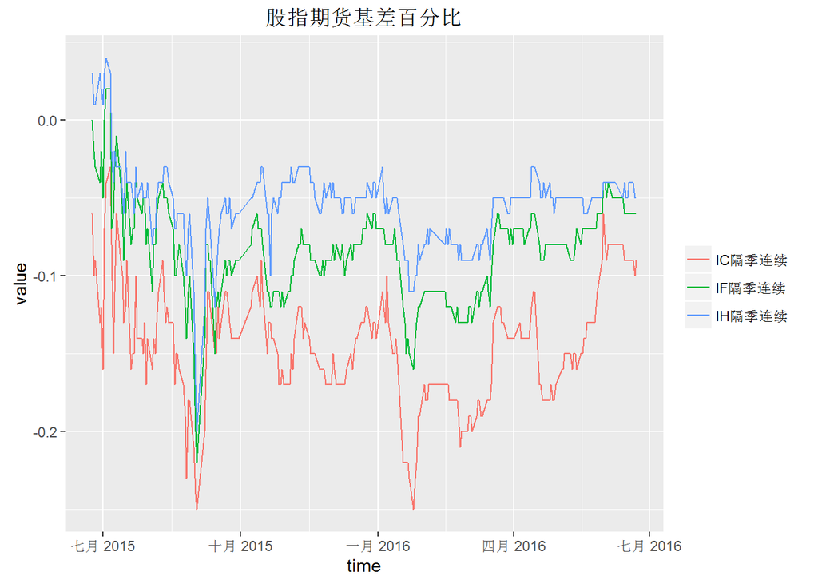

### (二)基差概况

三大股指期货连续合约基差概况如下表：

| 日期 | 合约简称 | 合约收盘价 | 基差 | 基差百分比 | 上周基差 | 上周基差百分比 |
| --- | --- | --- | --- | --- | --- | --- |
| 2016-06-22 | IH当月连续 | 2080.0 | -35.77 | -0.02 | -14.03 | -0.01 |
| 2016-06-22 | IH下月连续 | 2064.2 | -51.57 | -0.02 | -42.83 | -0.02 |
| 2016-06-22 | IH下季连续 | 2050.4 | -65.37 | -0.03 | -70.43 | -0.03 |
| 2016-06-22 | IH隔季连续 | 2019.0 | -96.77 | -0.05 | -99.63 | -0.05 |
| 2016-06-22 | IF当月连续 | 3076.0 | -57.96 | -0.02 | -16.37 | -0.01 |
| 2016-06-22 | IF下月连续 | 3036.2 | -97.76 | -0.03 | -62.77 | -0.02 |
| 2016-06-22 | IF下季连续 | 3004.0 | -129.96 | -0.04 | -119.97 | -0.04 |
| 2016-06-22 | IF隔季连续 | 2942.0 | -191.96 | -0.06 | -176.37 | -0.06 |
| 2016-06-22 | IC当月连续 | 5922.0 | -86.89 | -0.01 | -32.85 | -0.01 |
| 2016-06-22 | IC下月连续 | 5813.0 | -195.89 | -0.03 | -125.85 | -0.02 |
| 2016-06-22 | IC下季连续 | 5730.6 | -278.29 | -0.05 | -325.25 | -0.05 |
| 2016-06-22 | IC隔季连续 | 5497.2 | -511.69 | -0.09 | -524.65 | -0.09 |

## 三、套利

### (一)复牌股票套利

近两天复牌股票套利情况如下表：

[1] “无复牌股票套利”

## 四、择时

### (一)大盘均线强弱指数

大盘均线强弱指数在一定程度上可以视为一个反转指标，当大盘均线得分接近8分时，预示市场接近顶部，当大盘均线得分接近0分时，预示市场接近底部。  
大盘均线强弱指数近一年来走势如下图：

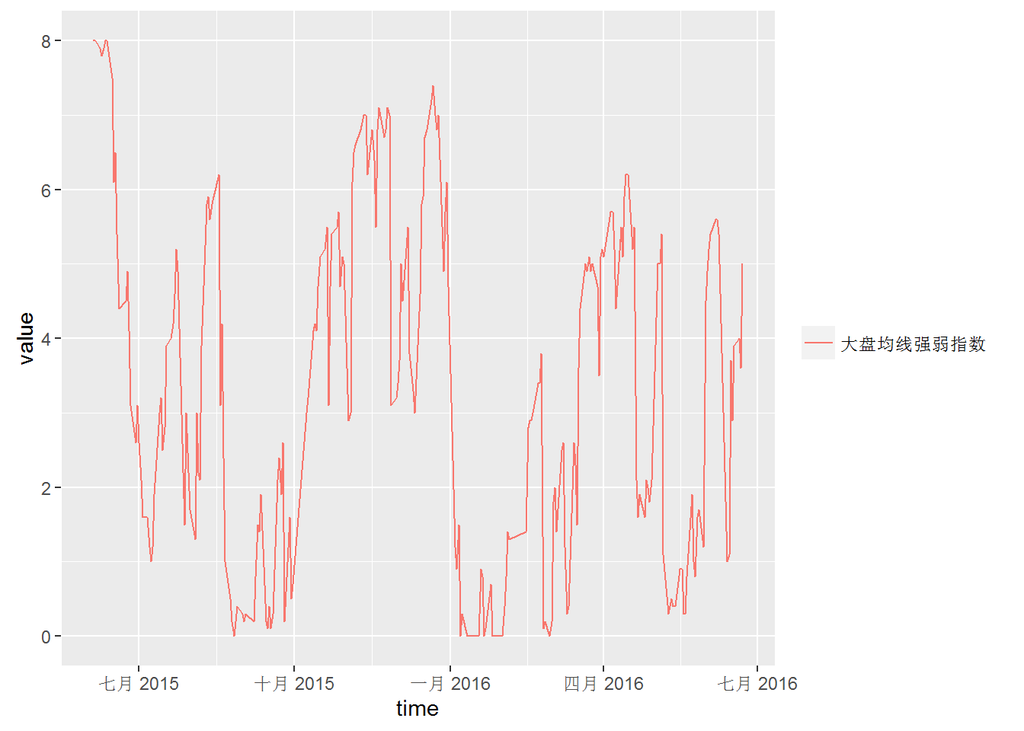

申万一级行业的最新得分及上周得分见下表：

| 日期 | 指数代码 | 指数名称 | 最新值 | 上周值 |
| --- | --- | --- | --- | --- |
| 2016-06-22 | EI801050 | 申万有色金属 | 8 | 8 |
| 2016-06-22 | EI801080 | 申万电子 | 8 | 8 |
| 2016-06-22 | EI801110 | 申万家用电器 | 8 | 7 |
| 2016-06-22 | EI801120 | 申万食品饮料 | 8 | 8 |
| 2016-06-22 | EI801880 | 申万汽车 | 8 | 8 |
| 2016-06-22 | EI801730 | 申万电气设备 | 7 | 6 |
| 2016-06-22 | EI801780 | 申万银行 | 7 | 3 |
| 2016-06-22 | EI801010 | 申万农林牧渔 | 6 | 5 |
| 2016-06-22 | EI801030 | 申万化工 | 6 | 5 |
| 2016-06-22 | EI801140 | 申万轻工制造 | 6 | 6 |
| 2016-06-22 | EI801150 | 申万医药生物 | 6 | 4 |
| 2016-06-22 | EI801740 | 申万国防军工 | 6 | 4 |
| 2016-06-22 | EI801750 | 申万计算机 | 6 | 5 |
| 2016-06-22 | EI801770 | 申万通信 | 6 | 5 |
| 2016-06-22 | EI801790 | 申万非银金融 | 6 | 3 |
| 2016-06-22 | EI801890 | 申万机械设备 | 6 | 6 |
| 2016-06-22 | EI801230 | 申万综合 | 5 | 3 |
| 2016-06-22 | EI801020 | 申万采掘 | 4 | 0 |
| 2016-06-22 | EI801160 | 申万公用事业 | 4 | 2 |
| 2016-06-22 | EI801180 | 申万房地产 | 4 | 1 |
| 2016-06-22 | EI801710 | 申万建筑材料 | 4 | 1 |
| 2016-06-22 | EI801130 | 申万纺织服装 | 2 | 1 |
| 2016-06-22 | EI801210 | 申万休闲服务 | 2 | 2 |
| 2016-06-22 | EI801720 | 申万建筑装饰 | 2 | 1 |
| 2016-06-22 | EI801040 | 申万钢铁 | 1 | 1 |
| 2016-06-22 | EI801170 | 申万交通运输 | 1 | 0 |
| 2016-06-22 | EI801200 | 申万商业贸易 | 1 | 1 |
| 2016-06-22 | EI801760 | 申万传媒 | 1 | 0 |

### (二)LLT及均线择时

LLT本质上是一个改进的单均线择时指标，较原始的均线择时延迟更低。  
择时模型和指数本身的净值走势如下图：

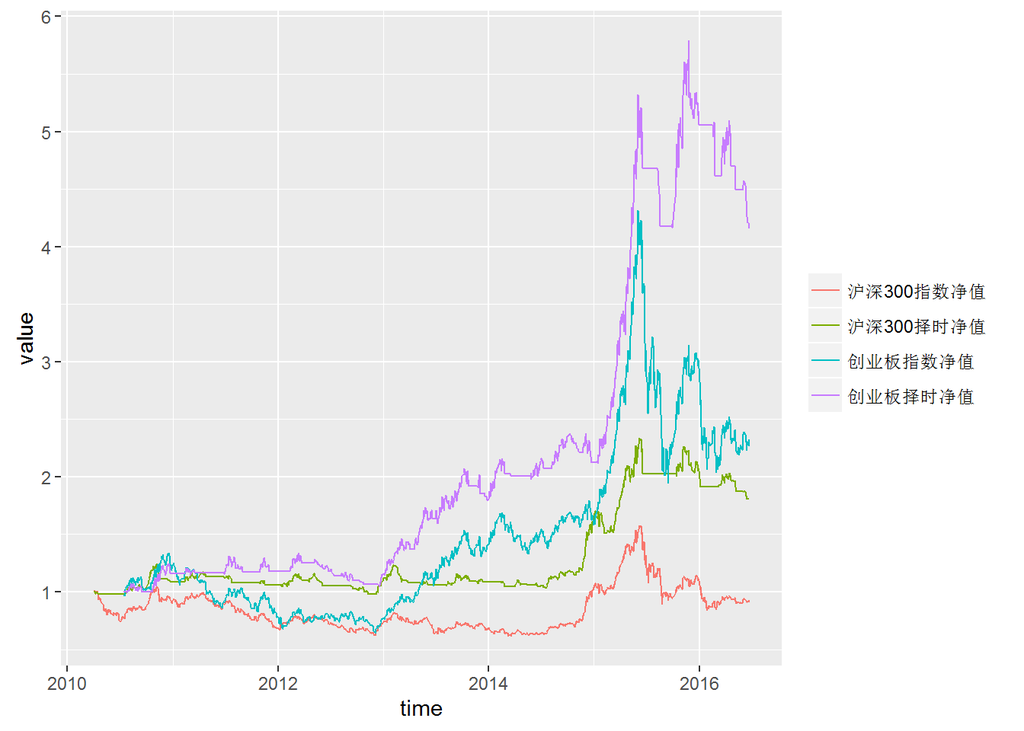

择时模型和指数的收益率统计如下表：

|  | 沪深300指 | 沪深300LLT | 创业板指 | 创业板MA |
| --- | --- | --- | --- | --- |
| 年化收益率 | -1.3 | 10.4 | 15.9 | 28.3 |
| 年化波动率 | 26.0 | 16.5 | 35.0 | 24.1 |
| 年化Sharpe值 | -5.0 | 63.0 | 45.4 | 117.3 |
| 最大回撤 | 46.7 | 22.6 | 54.9 | 28.3 |

择时模型最近10个交易日的信号如下表：

| 日期 | 沪深300收盘价 | 沪深300择时信号 | 创业板收盘价 | 创业板择时信号 |
| --- | --- | --- | --- | --- |
| 2016-06-07 | 3177.054 | hold | 2196.727 | hold |
| 2016-06-08 | 3163.986 | hold | 2186.544 | hold |
| 2016-06-13 | 3066.341 | sell | 2054.707 | sell |
| 2016-06-14 | 3075.983 |  | 2058.314 |  |
| 2016-06-15 | 3116.368 |  | 2128.799 | buy |
| 2016-06-16 | 3094.675 |  | 2101.416 | sell |
| 2016-06-17 | 3110.357 |  | 2122.890 | buy |
| 2016-06-20 | 3112.674 |  | 2119.630 | hold |
| 2016-06-21 | 3106.318 |  | 2092.001 | sell |
| 2016-06-22 | 3133.961 | buy | 2144.818 | buy |

### (三)网格交易

在经历了三轮股灾，A股逐步回归正常，在过去的一段时间呈现一个震荡的格局，如果未来没有增量信息，很可能维持震荡。结合股指期货的贴水，前期研究了一下网格交易。网格交易的结果如下图：

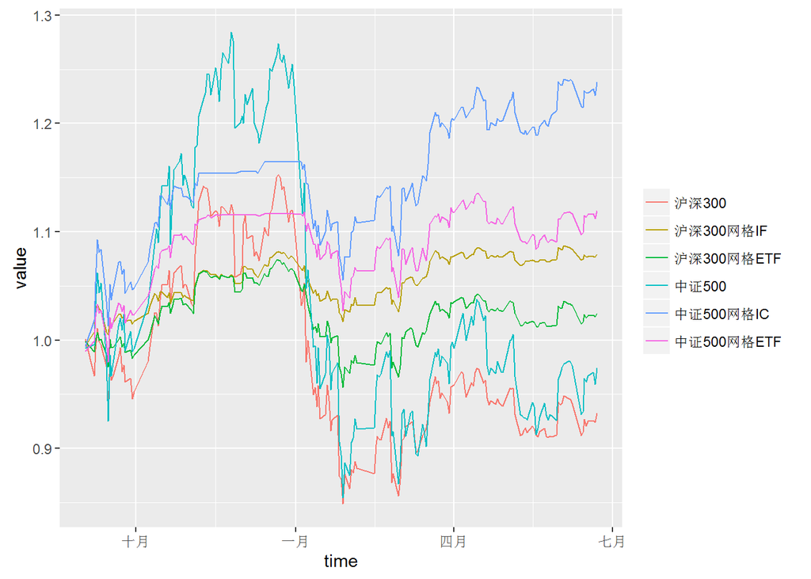

网格交易的收益统计如下表：

|  | 沪深300 | 沪深300网格IF | 沪深300网格ETF | 中证500 | 中证500网格IC | 中证500网格ETF |
| --- | --- | --- | --- | --- | --- | --- |
| 年化收益率 | -8.7 | 10.4 | 3.3 | -3.4 | 32.0 | 15.8 |
| 年化波动率 | 29.4 | 8.4 | 12.7 | 39.9 | 18.4 | 14.6 |
| 年化Sharpe值 | -29.6 | 124.0 | 25.6 | -8.4 | 174.4 | 108.2 |
| 最大回撤 | 26.4 | 5.9 | 10.9 | 33.5 | 9.4 | 8.2 |